# Fitting Data to a Seasonal ARIMA Process Step by Step in R

Alva Liu

```r
library(itsmr)
library(forecast)
```

## Data Exploration

The time series chosen for this tutorial is the Global Temperatures by Month data and can be downloaded from [Kaggle](https://www.kaggle.com/berkeleyearth/climate-change-earth-surface-temperature-data/data). Only the last 432 observations of the dataset, ranging from January 1980 to December 2015 sampled monthly, were used in this step by step model fit.

The data is read from the csv file, and transformed into a time series object with frequency 12 (monthly data) in the follwoing code section. The tsclean function from the forecast library was used for finding and replacing outliers and missing values. The cleaned data is shown in the plot below.

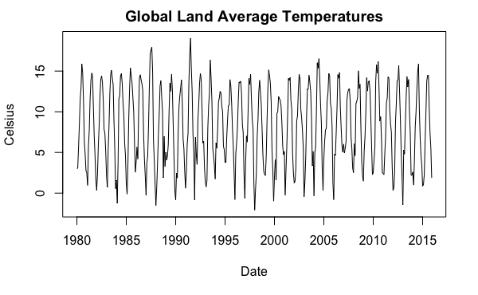

```r
data <- read.csv("GlobalTemperatures.csv")
ts <- ts(data$LandAverageTemperature, start=c(1980,1), end=c(2015, 12), frequency=12)
ts <- tsclean(ts)
plot(ts, main="Global Land Average Temperatures", xlab= "Date", ylab="Celsius")
```

From just looking at the time series, it is possible to see that it has a seasonal component. The data does not have any apparent trend. The stl function from the stats library was used to decompose the time series into a trend component, a seasonal component and residuals to confirm our assumptions about trend and seasonality. The plots below shows that the time series indeed has a strong seasonal pattern but no clear trend.

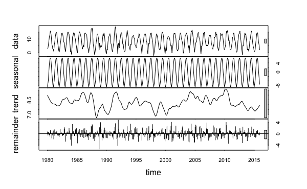

```r
decomp <- stl(ts, s.window = "periodic")
plot(decomp)
```

Since the data is seasonal, it is not stationary. This can be confirmed by using the test function in the itsmr library that conducts several tests with the null hypothesis being that the time series is i.i.d. noise. The results from the *Ljung-Box*, *McLeod-Li* and *Turning Points* tests all reject the null hypothesis with p-values below 0.05. The *ACF* and *PACF* also indicate that the data is not stationary but have a clear seasonal pattern. Also, the *QQ-plot* is not entirely diagonal.

```
Null hypothesis: Residuals are iid noise.
Test                        Distribution Statistic   p-value
Ljung-Box Q                Q ~ chisq(20)   3327.81         0 *
McLeod-Li Q                Q ~ chisq(20)   3015.82         0 *
Turning points T  (T-286.7)/8.7 ~ N(0,1)       127         0 *
Diff signs S        (S-215.5)/6 ~ N(0,1)       210    0.3599
Rank P         (P-46548)/1499.1 ~ N(0,1)     46621    0.9612
```

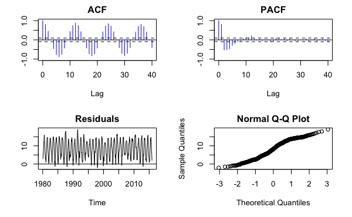

```r
test(ts)
```

## Fitting Data to a Model

Due to the clear seasonal pattern, the data can be fitted to a *seasonal ARIMA* process of the form
$$ARIMA(p,d,q)(P,D,Q)_s$$
where s is the period, p the AR-order, d the non-seasonal differece order, q the MA-order, P the SAR-order, D the seasonal differece order and Q the SMA-order. The following steps motivate how the orders of the seasonal ARIMA model can be found.

### Step 1:

Since the data exhibits a strong pattern of seasonality, it makes sense to add a seasonal difference to the model, giving
$$ARIMA(0,0,0)(0,1,0)_{12}$$

The residuals, ACF, PACF, AIC and RMSE of the model are shown below.

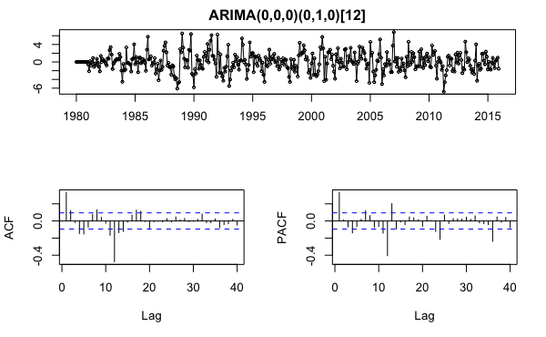

```r
model <- Arima(ts, order=c(0,0,0), seasonal = list(order=c(0,1,0), period=12))
tsdisplay(model$residuals, main = "ARIMA(0,0,0)(0,1,0)[12]", lag.max = 40)
```

```r
AIC(model)
```

```
[1] 1870.219
```

```r
accuracy(model)
```

```
                      ME     RMSE      MAE       MPE     MAPE      MASE
Training set -0.02843502 2.205702 1.668618 -6.434076 62.92433 0.9723581
                  ACF1
Training set 0.3304112
```

### Step 2:

From the previous step, we can see in the ACF that there is a clear spike at lag 12. The PACF has clear repeating spikes at multiples of the season (12, 24, 36, …) that are exponentially decreasing. This is the signature of the seasonal MA process, and we therefore add a SMA component to the model.

$$ARIMA(0,0,0)(0,1,1)_{12}$$

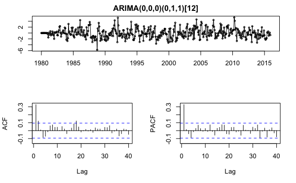

```r
model <- Arima(ts, order=c(0,0,0), seasonal = list(order=c(0,1,1), period=12))
tsdisplay(model$residuals, main = "ARIMA(0,0,0)(0,1,1)[12]", lag.max = 40)
```

```r
AIC(model)
```

```
[1] 1647.437
```

```r
accuracy(model)
```

```
                      ME     RMSE      MAE      MPE     MAPE      MASE
Training set -0.03900381 1.603609 1.239251 1.942058 46.25344 0.7221523
                  ACF1
Training set 0.3272823
```

### Step 3:

The ACF above is now looking like an AR(2) process. It is therefore reasonable to add two AR-components to the model, giving:

$$ARIMA(2,0,0)(0,1,1)_{12}$$

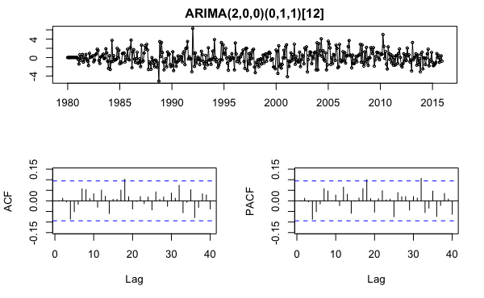

```r
model <- Arima(ts, order=c(2,0,0), seasonal = list(order=c(0,1,1), period=12))
tsdisplay(model$residuals, main = "ARIMA(2,0,0)(0,1,1)[12]", lag.max = 40)
```

```r
AIC(model)
```

```
[1] 1603.586
```

```r
accuracy(model)
```

```
                      ME     RMSE      MAE      MPE     MAPE      MASE
Training set -0.02965165 1.533852 1.188535 4.303989 45.57687 0.6925984
                     ACF1
Training set 0.0007124987
```

The ACF and PACF are now within the bounds of $\pm 1.96 / \sqrt n$ for almost all lags up to lag 40. This model can therefore be considered as a sufficiently reasonable fit to the data. The test function in the itsmr library can be applied again to test for randomness of the residuals.

```
Null hypothesis: Residuals are iid noise.
Test                        Distribution Statistic   p-value
Ljung-Box Q                Q ~ chisq(20)     17.94    0.5913
McLeod-Li Q                Q ~ chisq(20)      24.1    0.2382
Turning points T  (T-286.7)/8.7 ~ N(0,1)       273    0.1181
Diff signs S        (S-215.5)/6 ~ N(0,1)       225    0.1138
Rank P         (P-46548)/1499.1 ~ N(0,1)     46690    0.9245
```

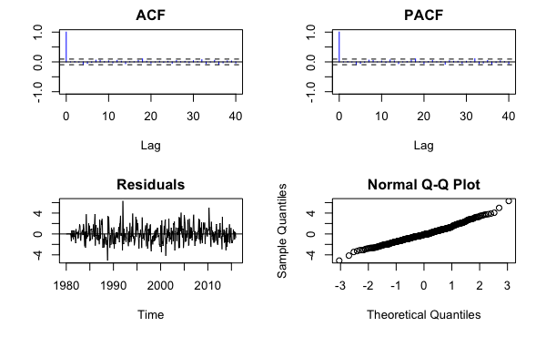

```r
test(model$residuals)
```

Since all of the p-values are greater than 0.05, there is no reason to reject the null hypothesis, and we can conclude that we have found a seasonal ARIMA process that fits the data.